# re_airquality

Elia Cornali

2025-05-19

## Setup

```r
# Import libraries

library(ggplot2)
library(readr)
library(lubridate)
library(dplyr)
library(datasets)
library(tidyverse)
```

## Description of the dataset

```r
# Save airquality dataset as variable

mean_ozone <- datasets::airquality
```

The “airquality” data frame shows the daily air quality measurements in New York, from May to September 1973. It contains 153 observations for 6 distinct variables. There are two time variables, namely “Month” and “Day”, and 4 quantities of interest (e.g., Ozone, Solar.R, Wind and Temp). The Ozone variable indicates the mean ozone in parts per billion (ppb) from 1300 to 1500 hours at Roosevelt Island. The Solar. R variable shows the solar radiation in Langleys (Ly) in the frequency band 4000 - 7700 Angstroms from 0800 to 1200 hours at Central Park. The Wind variable refers to the average wind speed in miles per hour (mph) at 0700 and 1000 hours at LaGuardia Airport and the Temp variable depicts the maximum daily temperature in degrees Fahrenheit (F) at LaGuardia Airport. The data were obtained from the Ney York State Department of Conservation (ozone data) and the National Weather Service (meteorological data) (Chamber et al., 1983)

## Data quality analysis

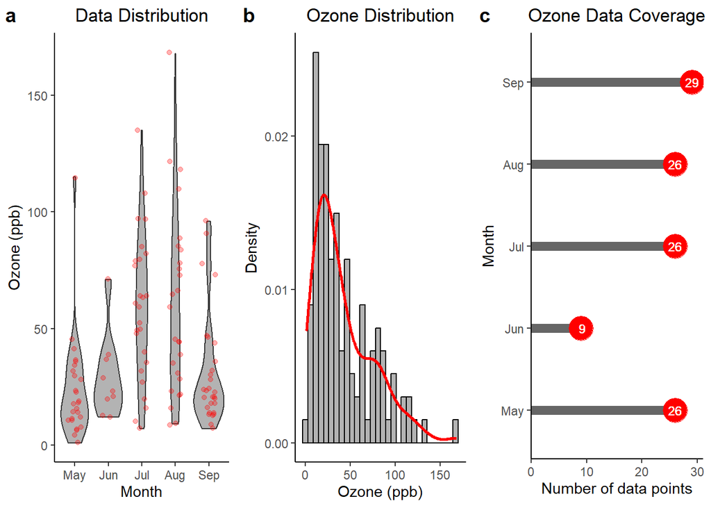

```r
# Prepare plot data
# Mutate month variable

mean_ozone_month <- mean_ozone |>

  mutate(Month = month(Month, label = TRUE))

# Identify data coverage per month
mean_ozone_nr_values = mean_ozone_month |>

  mutate(Nr_Values = ifelse(is.na(Ozone) == FALSE, 1, 0)) |>

  group_by(Month) |>

  reframe(Month, Nr_Values = sum(Nr_Values))



# Violin plot + jittered points
plot_1 <- ggplot(
  data = mean_ozone_month,
  aes(x = Month, y = Ozone)) +
  geom_violin(fill = "grey70", outlier.shape = NA) +
  geom_jitter(width = 0.2, alpha = 0.3, color = "red") +
  labs(title = "Data Distribution",
       x = "Month",
       y = "Ozone (ppb)") +
  theme_classic() +
  theme(plot.title = element_text(hjust = 0.5))
# Density plot
plot_2 <- ggplot(
  data = mean_ozone_month,
  aes(x = Ozone, y = ..density..)) +
  geom_histogram(fill = "grey70", color = "black") +
  geom_density(color = "red", linewidth = 1) +
  labs(title = "Ozone Distribution",
       x = "Ozone (ppb)",
       y = "Density") +
  theme_classic() +
  theme(plot.title = element_text(hjust = 0.5))


# Custom plot
plot_3 <- ggplot(
  data = mean_ozone_nr_values,
  aes(x = Month, y = Nr_Values)) +
  geom_segment(aes(x = Month, xend = Month, y = 0, yend = Nr_Values),
               size = 3, color = "grey40") +
  geom_point(aes(x = Month, y = Nr_Values), size = 8, color = "red") +
  geom_text(aes(x = Month, y = Nr_Values, label = format(Nr_Values, digits = 2)),
            size = 3, color = "white") +
  labs(title = "Ozone Data Coverage",
       x = "Month",
       y = expression(paste("Number of data points"))) +
  scale_y_continuous(limits = c(0, 31), expand = c(0, 0)) +
  coord_flip() +
  theme_classic() +
  theme(plot.title = element_text(hjust = 0.5))
# Cowplot
figure_1 <- cowplot::plot_grid(
  data = plot_1, plot_2, plot_3,
  ncol = 3,
  labels = "auto")
# Save figure in repository figures
ggplot2::ggsave(
  filename = here::here("figures", "Data quality analysis.png"),
  plot = figure_1,
  width = 10, height = 6, dpi = 300
)

# Depict plot in html version
figure_1
```

To analyse the data quality of the airquality dataset various plots are shown in the figure above.

Plot (a) depicts the distribution of Ozone data points for each month. The plot visualizes the range of Ozone concentration per month. Moreover, by analyzing the shape of the violin plots we can deduce that in the months of May, June and September Ozone values are concentrated between 0 and 50 (ppb), whereas Ozone concentrations during July and August are distributed over a wider range, with more values reaching higher concentrations of about 100 (ppb).

Plot (c) visualizes the number of data points per month. It can be seen, that the month of June holds less readings and is therefore less representative.

# Density of data points

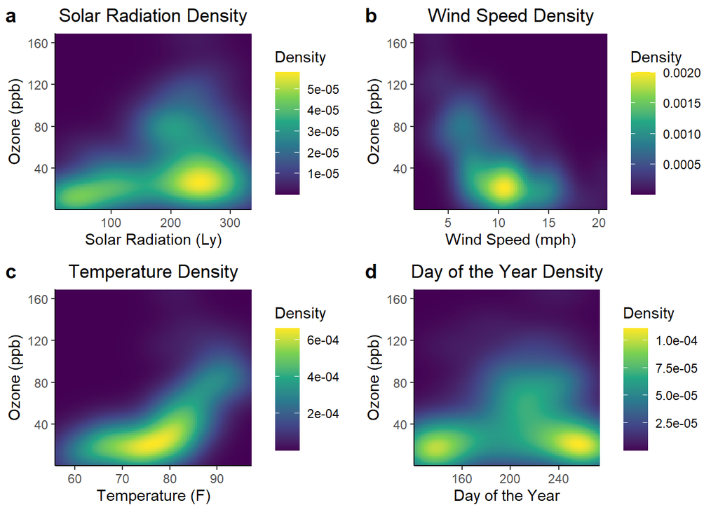

```r
# Prepare Data
# Display values ordered by day
mean_ozone_day <- mean_ozone |>

  mutate(Date = make_date(year = 1973 , month = Month, day = Day)) |>

  mutate(doy = yday(Date)) |>

  group_by(doy)

# Density raster for Solar Radiation

plot_6 <- ggplot(
    data = mean_ozone_month,
    aes(x = Solar.R, y = Ozone)) +
  stat_density_2d(
    geom = "raster", # the geometric object to display the data
    aes(fill = after_stat(density)), # using `density`, a variable calculated by the stat
    contour = FALSE
    ) +
  scale_fill_viridis_c() +
  labs(title = "Solar Radiation Density",
       x = "Solar Radiation (Ly)",
       y = "Ozone (ppb)",
       fill = "Density") +
  theme_classic() +
  theme(plot.title = element_text(hjust = 0.5)) +
  scale_x_continuous(expand = c(0, 0)) +  # avoid gap between plotting area and axis
  scale_y_continuous(expand = c(0, 0))

# Density plot for Wind
plot_7 <- ggplot(
    data = mean_ozone_month,
    aes(x = Wind, y = Ozone)) +
  stat_density_2d(
    geom = "raster", # the geometric object to display the data
    aes(fill = after_stat(density)), # using `density`, a variable calculated by the stat
    contour = FALSE
    ) +
  scale_fill_viridis_c() +
  labs(title = "Wind Speed Density",
       x = "Wind Speed (mph)",
       y = "Ozone (ppb)",
       fill = "Density") +
  theme_classic() +
  theme(plot.title = element_text(hjust = 0.5)) +
  scale_x_continuous(expand = c(0, 0)) +  # avoid gap between plotting area and axis
  scale_y_continuous(expand = c(0, 0))

# Density plot for Temperature
plot_8 <- ggplot(
    data = mean_ozone_month,
    aes(x = Temp, y = Ozone)) +
  stat_density_2d(
    geom = "raster", # the geometric object to display the data
    aes(fill = after_stat(density)), # using `density`, a variable calculated by the stat
    contour = FALSE
    ) +
  scale_fill_viridis_c() +
  labs(title = "Temperature Density",
       x = "Temperature (F)",
       y = "Ozone (ppb)",
       fill = "Density") +
  theme_classic() +
  theme(plot.title = element_text(hjust = 0.5)) +
  scale_x_continuous(expand = c(0, 0)) +  # avoid gap between plotting area and axis
  scale_y_continuous(expand = c(0, 0))

# Density plot for Day
plot_9 <- ggplot(
    data = mean_ozone_day,
    aes(x = doy, y = Ozone)) +
  stat_density_2d(
    geom = "raster", # the geometric object to display the data
    aes(fill = after_stat(density)), # using `density`, a variable calculated by the stat
    contour = FALSE
    ) +
  scale_fill_viridis_c() +
  labs(title = "Day of the Year Density",
       x = "Day of the Year",
       y = "Ozone (ppb)",
       fill = "Density") +
  theme_classic() +
  theme(plot.title = element_text(hjust = 0.5)) +
  scale_x_continuous(expand = c(0, 0)) +  # avoid gap between plotting area and axis
  scale_y_continuous(expand = c(0, 0))

# Combine plots
figure_2 <- cowplot::plot_grid(
  data = plot_6, plot_7, plot_8, plot_9,
  ncol = 2,
  labels = "auto")
# Save figure in repository figures
ggplot2::ggsave(
  filename = here::here("figures", "Density of data points.png"),
  plot = figure_2,
  width = 10, height = 6, dpi = 300
)

# Depict plot in html version
figure_2
```

The Figure above shows the density of Ozone data points and various variables. Plot (a) depicts the density of data points between Ozone and Solar Radiation. The highest density of data points cover low Ozone concentration (~ 40 ppb) and high Solar Radiation (~ 250 Ly). Plot (b) visualizes the density of data points between Ozone and Wind Speed. The highest density of data points cover low Ozone concentration (~ 30 ppb) and mid Wind Speeds (~ 10 mph). Plot (c) shows the density of data points between Ozone and Temperature. The highest density of data points covers low Ozone concentration (~ 30) and mid Temperatures (between 70 and 80 F). Plot (d) depicts the density of data points between Ozone and the Day of the Year. The highest density of data points cover low Ozone concentration (between 20 and 30 ppb) and the earliest (140th Day) and latest time of the data set (250th Day).

## Seasonal trends of data

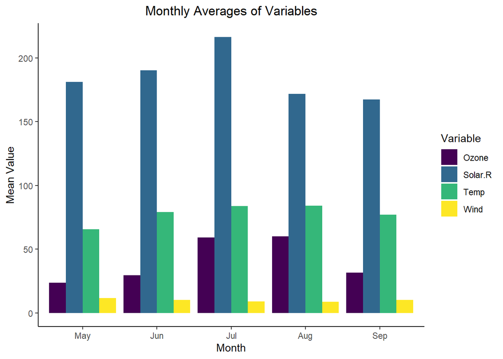

```r
# Prepare data
# Convert data to long format
mean_ozone_long_month <- mean_ozone_month |>

  select(Ozone, Solar.R, Wind, Temp, Month) |>

  pivot_longer(cols = -Month, names_to = "Variable", values_to = "Value") |>

  group_by(Month, Variable) |>

  summarise(MeanValue = mean(Value, na.rm = TRUE), .groups = "drop")


# Bar chart plot
figure_3 <- ggplot(
  data = mean_ozone_long_month,
  aes(x = factor(Month), y = MeanValue, fill = Variable)) +
  geom_bar(stat = "identity", position = "dodge") +
  scale_fill_viridis_d() +
  labs(title = "Monthly Averages of Variables",
       x = "Month",
       y = "Mean Value") +
  theme_classic() +
  theme(plot.title = element_text(hjust = 0.5))

# Save figure in repository figures
ggplot2::ggsave(
  filename = here::here("figures", "Seasonal trends of data.png"),
  plot = figure_3,
  width = 10, height = 6, dpi = 300
)

# Depict plot in html version
figure_3
```

## Impacts of solar radiation, wind and temperature on ozone concentration

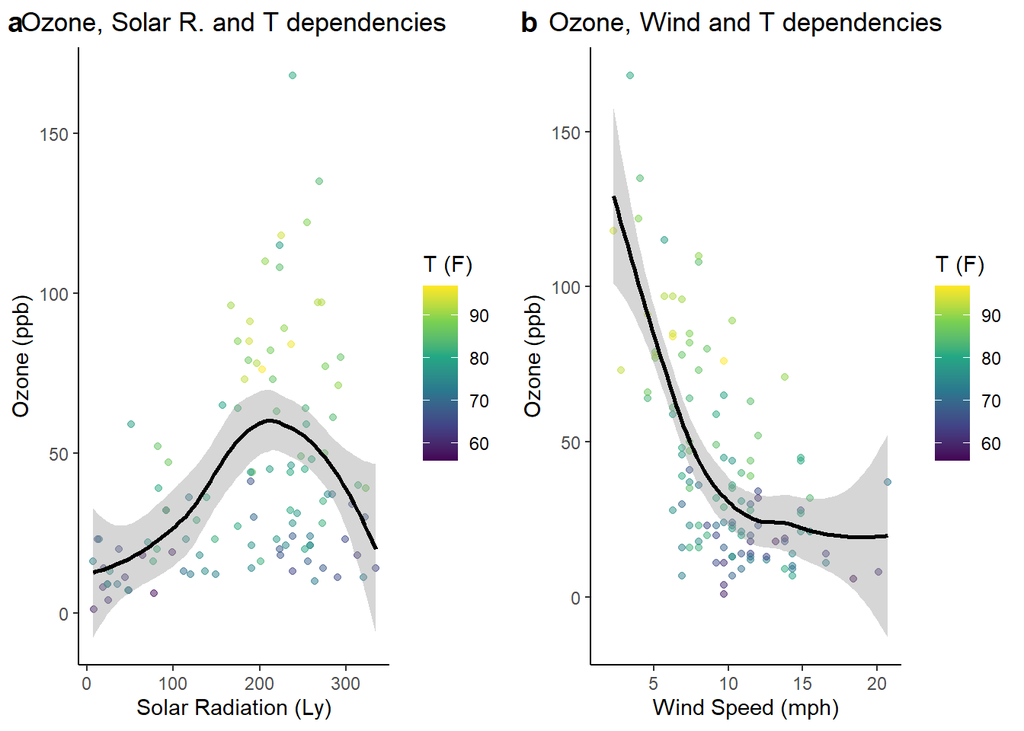

```r
# Ozone, Solar Radiation and Temperature plot
plot_4 <- ggplot(
  data = mean_ozone_month,
  aes(x = Solar.R, y = Ozone, color = Temp)) +
  geom_point(alpha = 0.5) +
  geom_smooth(color = "black") +
  theme_classic() +
  labs(title = "Ozone, Solar R. and T dependencies",
       x = "Solar Radiation (Ly)",
       y = "Ozone (ppb)",
       color = "T (F)") +
  scale_color_viridis_c() +
  theme(plot.title = element_text(hjust = 0.5))

# Ozone, Wind and Temperature plot
plot_5 <- ggplot(
  data = mean_ozone_month,
  aes(x = Wind, y = Ozone, color = Temp)) +
  geom_point(alpha = 0.5) +
  geom_smooth(color = "black") +
  scale_color_viridis_c() +
  labs(title = "Ozone, Wind and T dependencies",
       x = "Wind Speed (mph)",
       y = "Ozone (ppb)",
       color = "T (F)") +
  theme_classic() +
  theme(plot.title = element_text(hjust = 0.5))


# combine plots
figure_4 <- cowplot::plot_grid(
  data = plot_4, plot_5,
  ncol = 2,
  labels = "auto")
# Save figure in repository figures
ggplot2::ggsave(
  filename = here::here("figures", "Impacts of solar radiation, wind and temperature on ozone concentration.png"),
  plot = figure_4,
  width = 10, height = 6, dpi = 300
)

# Depict plot in html version
figure_4
```

Multiple variables were depicted in the scatter plots above, to further investigate dependencies within the dataset.

Plot (a) visualizes how Ozone concentrations vary in relation to Solar Radiation and Temperature. Ozone increases with increasing Solar Radiation until approximately 200 (Ly), followed by a decrease in concentration between 200 and 300 Ly.

Plot (b) depicts the co-dependency of Ozone and Wind Speed. At lower Wind Speeds (~ 5 mph) Ozone concentrations are highest (~ 120 ppb), further decreasing with increasing Wind Speeds. Therefore, we can deduce that Ozone concentration is inverse proportional to Wind Speeds. There is also a trend between Temperature and Wind Speeds, suggesting that Temperature decreases with higher Wind Speeds.

Both plots suggest that Ozone concentration is proportional to Temperature. High Ozone values are connected to high Temperatures and low Ozone Values to low Temperatures.

## References

Chambers, J. M., Cleveland, W. S., Kleiner, B. and Tukey, P. A. (1983) Graphical Methods for Data Analysis. Belmont, CA: Wadsworth.